# Mudanças no consumo de água durante a pandemia de COVID-19

## Pandemia, rotina e consumo de água

PROJETO I · Lucas Rodrigo de Moura Aragão · UFF

- **Social:** distanciamento e mudanças no convívio.
- **Econômico:** mudanças no trabalho e dificuldades financeiras.
- **Comportamental:** reorganização da alimentação e do autocuidado.

**A mudança no consumo de água se associa às características dos participantes?**

**Objetivo:** avaliar essa associação e identificar os perfis que se destacam na amostra.

Contexto: OMS (2020), estratégia de resposta à COVID-19; Malta et al. (2020), mudanças no estilo de vida dos brasileiros.

## Dados e variáveis

### Questionário online · 2022

**2.155 adultos** · pós-graduação em Nutrição da UFF.

Amostra de **conveniência**; respostas autorrelatadas.

**Resposta principal:** mudança no consumo de água.

**Diminuiu · Não alterou · Aumentou**

### Características comparadas

**15 qualitativas:** perfil social e econômico, contexto da pandemia e relatos emocionais.

**4 quantitativas:** idade, peso, altura e IMC.

**Preparação:** recusas excluídas apenas da variável correspondente; escolaridade agrupada em três níveis; categorias raras mantidas.

A resposta mede **mudança percebida**. Não informa litros ingeridos nem adequação da hidratação.

## Métodos estatísticos

### Qualitativas × água

- **Qui-quadrado** de independência.
- **Fisher** quando as frequências esperadas são pequenas.
- **Resíduos padronizados:** onde estão os desvios.
- **V de Cramér:** intensidade da associação.

### Quantitativas nos três grupos

- **Densidade, Q-Q e Shapiro–Wilk:** normalidade por grupo.
- **Levene:** comparação das variâncias.
- **Idade:** Welch + Games–Howell.
- **Peso, altura e IMC:** ANOVA + Tukey.

Nível de significância a 5%

## Quase metade relatou aumento

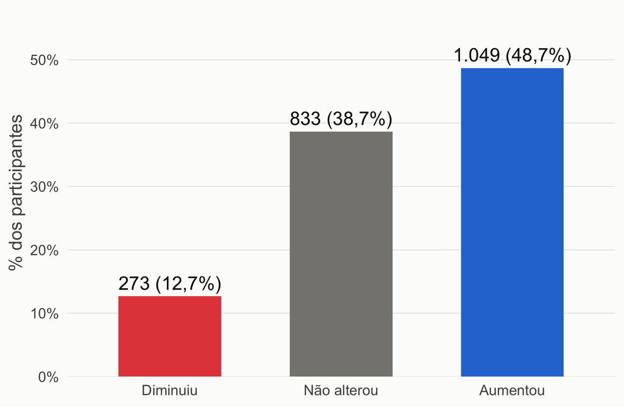

### Visão geral

**13 das 15** qualitativas: p < 0,05.

Associações **fracas ou muito fracas**.

**Trabalho e fumo:** sem evidência estatística suficiente.

Valor-p baixo não significa associação intensa.

## Perfil sociodemográfico

| Variável / categoria | Diminuiu | Não alterou | Aumentou |
| --- | --- | --- | --- |
| Gênero<sup>F</sup> · n = 2.150 · p < 0,001 · V = 0,080 |  |  |  |
| Feminino | **236 (14,7%)** | 605 (37,8%) | 761 (47,5%) |
| Masculino | **35 (6,5%)** | 227 (41,9%) | 280 (51,7%) |
| Outro | 2 (33,3%) | 1 (16,7%) | 3 (50,0%) |
| Raça/cor<sup>F</sup> · n = 2.127 · p 0,003 · V = 0,076 |  |  |  |
| Branca | 181 (13,4%) | **560 (41,6%)** | **605 (44,9%)** |
| Parda | 64 (11,1%) | **195 (33,9%)** | **317 (55,0%)** |
| Preta | 20 (12,0%) | **51 (30,7%)** | **95 (57,2%)** |
| Amarela | 3 (12,0%) | 11 (44,0%) | 11 (44,0%) |
| Indígena | 2 (22,2%) | 2 (22,2%) | 5 (55,6%) |
| Outro | 0 (0,0%) | 2 (40,0%) | 3 (60,0%) |

| Variável / categoria | Diminuiu | Não alterou | Aumentou |
| --- | --- | --- | --- |
| Região<sup>Q</sup> · n = 2.155 · p < 0,001 · V = 0,108 |  |  |  |
| Norte | **24 (7,9%)** | **99 (32,5%)** | **182 (59,7%)** |
| Nordeste | **44 (16,4%)** | **88 (32,8%)** | 136 (50,7%) |
| Centro-Oeste | 19 (8,8%) | 83 (38,2%) | 115 (53,0%) |
| Sudeste | 110 (12,1%) | 351 (38,7%) | 446 (49,2%) |
| Sul | **76 (16,6%)** | **212 (46,3%)** | **170 (37,1%)** |

**Redução:** mulheres 14,7%; homens 6,5%.

**Aumento:** Norte 59,7%; Sul 37,1%.

n (% na linha) · **Q** qui-quadrado · **F** Fisher por Monte Carlo · **V** de Cramér · **Em negrito:** caselas influentes (|resíduo padronizado| > 1,96 e p < 0,05)

## Condições econômicas e contexto da pandemia

| Variável / categoria | Diminuiu | Não alterou | Aumentou |
| --- | --- | --- | --- |
| Renda familiar<sup>Q</sup> · n = 2.155 · p 0,003 · V = 0,060 |  |  |  |
| Até R$ 1.254 | 39 (15,9%) | **80 (32,7%)** | 126 (51,4%) |
| R$ 1.255 a R$ 8.640 | 158 (12,8%) | **452 (36,7%)** | 620 (50,4%) |
| Mais de R$ 8.640 | 76 (11,2%) | **301 (44,3%)** | **303 (44,6%)** |
| Escolaridade<sup>Q</sup> · n = 2.138 · p < 0,001 · V = 0,073 |  |  |  |
| Até Ensino Médio | **118 (15,8%)** | **246 (32,9%)** | 384 (51,3%) |
| Ensino Superior Completo | 51 (12,3%) | 159 (38,2%) | 206 (49,5%) |
| Pós-graduação | **102 (10,5%)** | **419 (43,0%)** | 453 (46,5%) |
| Dificuldade financeira<sup>Q</sup> · n = 2.155 · p < 0,001 · V = 0,092 |  |  |  |
| Não | **204 (11,6%)** | **713 (40,5%)** | 844 (47,9%) |
| Sim | **69 (17,5%)** | **120 (30,5%)** | 205 (52,0%) |

| Variável / categoria | Diminuiu | Não alterou | Aumentou |
| --- | --- | --- | --- |
| Isolamento social<sup>Q</sup> · n = 2.155 · p 0,022 · V = 0,060 |  |  |  |
| Não | 115 (12,1%) | **399 (41,9%)** | **438 (46,0%)** |
| Sim | 158 (13,1%) | **434 (36,1%)** | **611 (50,8%)** |
| Diagnóstico de COVID-19<sup>Q</sup> · n = 2.155 · p 0,017 · V = 0,062 |  |  |  |
| Não | **217 (13,8%)** | 611 (38,9%) | **744 (47,3%)** |
| Sim | **56 (9,6%)** | 222 (38,1%) | **305 (52,3%)** |
| Consulta com nutricionista<sup>Q</sup> · n = 2.155 · p 0,002 · V = 0,077 |  |  |  |
| Não | 222 (12,7%) | **705 (40,4%)** | **820 (46,9%)** |
| Sim | 51 (12,5%) | **128 (31,4%)** | **229 (56,1%)** |

n (% na linha) · **Q** qui-quadrado · **F** Fisher por Monte Carlo · **V** de Cramér · **Em negrito:** caselas influentes (|resíduo padronizado| > 1,96 e p < 0,05)

**Dificuldade financeira:** redução em 17,5% com relato e 11,6% sem relato. Consulta com nutricionista associa-se a mais aumento.

## Saúde emocional, trabalho e fumo

| Variável / categoria | Diminuiu | Não alterou | Aumentou |
| --- | --- | --- | --- |
| Ansiedade<sup>Q</sup> · n = 2.155 · p < 0,001 · V = 0,138 |  |  |  |
| Não | **99 (8,9%)** | **485 (43,7%)** | 525 (47,3%) |
| Sim | **174 (16,6%)** | **348 (33,3%)** | 524 (50,1%) |
| Depressão<sup>Q</sup> · n = 2.155 · p < 0,001 · V = 0,117 |  |  |  |
| Não | **199 (11,0%)** | **723 (40,0%)** | 884 (48,9%) |
| Sim | **74 (21,2%)** | **110 (31,5%)** | 165 (47,3%) |
| Insônia<sup>Q</sup> · n = 2.155 · p < 0,001 · V = 0,083 |  |  |  |
| Não | **216 (11,6%)** | 735 (39,5%) | 912 (49,0%) |
| Sim | **57 (19,5%)** | 98 (33,6%) | 137 (46,9%) |
| Enxaqueca<sup>Q</sup> · n = 2.155 · p 0,020 · V = 0,060 |  |  |  |
| Não | **220 (12,0%)** | **728 (39,6%)** | 892 (48,5%) |
| Sim | **53 (16,8%)** | **105 (33,3%)** | 157 (49,8%) |

| Variável / categoria | Diminuiu | Não alterou | Aumentou |
| --- | --- | --- | --- |
| Trabalha<sup>Q</sup> · n = 2.155 · p 0,123 · V = 0,044 |  |  |  |
| Não | 79 (13,8%) | 201 (35,1%) | 292 (51,0%) |
| Sim | 194 (12,3%) | 632 (39,9%) | 757 (47,8%) |
| Fuma<sup>Q</sup> · n = 2.155 · p 0,093 · V = 0,047 |  |  |  |
| Não | 258 (12,6%) | 803 (39,2%) | 989 (48,2%) |
| Sim | 15 (14,3%) | 30 (28,6%) | 60 (57,1%) |

**Depressão e redução:** 21,2% com relato; 11,0% sem relato.

Trabalho e fumo: **p ≥ 0,05**.

n (% na linha) · **Q** qui-quadrado · **F** Fisher por Monte Carlo · **V** de Cramér · **Em negrito:** caselas influentes (|resíduo padronizado| > 1,96 e p < 0,05)

## Idade e medidas antropométricas

| Variável / medida | Diminuiu n = 273 | Não alterou n = 833 | Aumentou n = 1.049 | p | η² |
| --- | --- | --- | --- | --- | --- |
| Idade (anos)<sup>W</sup> Média (DP) | 31,3 (11,0)<sup>c</sup> | 36,4 (12,7)<sup>a</sup> | 34,5 (12,6)<sup>b</sup> | < 0,001 | 0,016 |
| Mediana [Q1; Q3] | 27,0 [23,0; 38,0] | 35,0 [26,0; 44,0] | 31,0 [23,0; 43,0] |  |  |
| Peso (kg)<sup>A</sup> Média (DP) | 67,8 (16,2)<sup>b</sup> | 70,9 (15,9)<sup>a</sup> | 70,4 (15,9)<sup>a</sup> | 0,021 | 0,004 |
| Mediana [Q1; Q3] | 65,0 [55,5; 76,0] | 68,0 [59,0; 80,0] | 68,0 [59,0; 80,0] |  |  |
| Altura (m)<sup>A</sup> Média (DP) | 1,65 (0,08) | 1,66 (0,09) | 1,66 (0,08) | 0,095 | 0,002 |
| Mediana [Q1; Q3] | 1,63 [1,59; 1,70] | 1,65 [1,60; 1,71] | 1,65 [1,59; 1,71] |  |  |
| IMC (kg/m²)<sup>A</sup> Média (DP) | 25,0 (5,5) | 25,7 (5,1) | 25,6 (5,0) | 0,146 | 0,002 |
| Mediana [Q1; Q3] | 24,2 [21,2; 27,3] | 24,9 [21,9; 28,4] | 24,8 [22,0; 28,4] |  |  |

A = ANOVA + Tukey · W = Welch + Games–Howell · letras compartilhadas: diferença não detectada no pós-teste (5%).

**Idade média:** Diminuiu 31,3 < Aumentou 34,5 < Não alterou 36,4 anos. Peso não resiste ao Bonferroni; altura e IMC sem evidência de diferença.

## Água e outros hábitos

Análise exploratória complementar · outros desfechos do banco

| Variável / categoria | Diminuiu | Não alterou | Aumentou |
| --- | --- | --- | --- |
| Mudança no consumo de frutas<sup>Q</sup> · n = 2.155 · p < 0,001 · V = 0,214 |  |  |  |
| Diminuiu | **117 (26,7%)** | **151 (34,4%)** | **171 (39,0%)** |
| Não alterou | **77 (9,6%)** | **410 (51,4%)** | **311 (39,0%)** |
| Aumentou | **79 (8,6%)** | **272 (29,6%)** | **567 (61,8%)** |

n (% na linha) · **Q** qui-quadrado · **F** Fisher por Monte Carlo · **V** de Cramér · **Em negrito:** caselas influentes (|resíduo padronizado| > 1,96 e p < 0,05)

- Entre quem **aumentou frutas**, **61,8% aumentaram água**.
- Entre quem **diminuiu frutas**, **26,7% diminuíram água**.
- V = **0,214**: mudanças relacionadas, com intensidade **fraca**.

## Conclusão e limites

- **Resultado geral:** quase metade relatou aumento de água.
- **Perfis de redução:** relatos emocionais, dificuldade financeira e menor idade se destacaram.
- **Intensidade:** associações fracas ou muito fracas; significância não equivale a grande efeito.

**Amostra de conveniência · autorrelato · análises bivariadas**

Os resultados descrevem associações nesta amostra. Não demonstram causalidade nem controlam outras características simultaneamente.

**Contribuição:** sugerir perfis a observar em ações de promoção da hidratação em situações de crise.